# Potential Aquaculture Locations within Exclusive Economic Zones

Author

Sofia Rodas

Published

November 30, 2025

## Introduction

Aquaculture is a viable solution to help address over-fishing while providing ocean foods to communities that rely on them. It additionally creates a job sector increasing local employment opportunities. Though there are many factors in choosing suitable locations for aquaculture, sea surface temperature (SST) and bathymetry are two key considerations. This analysis focuses on creating a function that identifies potential aquaculture locations based on SST and bathymetry species requirements. Further, the findings of potential aquaculture locations for each species is broken into Exclusive Economic Zones (EEZ).

```r
# load in necessary libraries
library(tidyverse)
library(sf)
library(terra)
library(tmap)
library(patchwork)
library(kableExtra)
```

## Read in data

```r
# read in eez data as an sf object
eez_sf <- read_sf(here::here("data","wc_regions_clean.shp"))
```

```r
# read in raster depth data
depth <- rast(here::here("data", "depth.tif"))
```

```r
# read in raster sea surface temperature data
sst_2008 <- rast(here::here("data", "average_annual_sst_2008.tif"))
sst_2009 <- rast(here::here("data", "average_annual_sst_2009.tif"))
sst_2010 <- rast(here::here("data", "average_annual_sst_2010.tif"))
sst_2011 <- rast(here::here("data", "average_annual_sst_2011.tif"))
sst_2012 <- rast(here::here("data", "average_annual_sst_2012.tif"))

# stack data into a raster stack
sst <- c(sst_2008, sst_2009, sst_2010, sst_2011, sst_2012)
```

```r
# remove unnecessary raster data
rm(sst_2008, sst_2009, sst_2010, sst_2011, sst_2012)
```

## Check CRS

Note: To check the CRS of a raster use crs. To check the CRS of a simple feature object use st_crs.

```r
  if (crs(sst)== crs(depth)){
  print("it's a match!")
}else {
    warning("still not a match")
}
```

Make all of the CRS match the SST CRS.

```r
depth <- project(depth, crs(sst))
eez_sf <- st_transform(eez_sf, crs(sst))
```

Make sure the CRS alterations were successful.

```r
  if (crs(sst)== crs(depth)){
  print("it's a match!")
}else {
    warning("still not a match")
}
```

```
[1] "it's a match!"
```

## Data processing

This analysis works based on the mean of Sea Surface Temperature (SST) measured between 2008 and 2012.

```r
# calculate the mean of sst
mean_sst <- mean(sst)

# convert the units from kelvin to celcius
mean_sst <- mean_sst - 273
```

This analysis requires SST and depth to have the same extent, resolution, and positions. Crop to make sure the extent of the rasters are the same.

```r
# crop the depth raster
depth <- crop(depth, mean_sst)
```

Resample to make sure that the resolutions of the rasters are the same.

```r
depth <- resample(depth, mean_sst)
```

Make sure the extents and resolutions match for the SST and depth data frames.

```r
  if (ext(mean_sst)== ext(depth)){
  print("extents match!")
}else {
    warning("extents not a match")
}
```

```
[1] "extents match!"
```

```r
if (res(mean_sst)[1]== res(depth)[1] & res(mean_sst)[2]== res(depth)[2]){
   print("resolutions match!")
 }else {
     warning("resolutions not a match")
 }
```

```
[1] "resolutions match!"
```

# Find cells where conditions are satisfied for both the sst and depth for specific species.

1. Make a matrix
2. Reclassify based on that matrix

Sea surface temperature is adequate for oysters in the range of 11-30°C. Classify sea surface temperature to find those areas that are potential zones for oyster aquaculture.

```r
# create a classification matrix for sst
sst_matrix <- matrix(c(-Inf, 11, 0,
            11, 30, 1,
            30, Inf, 0),
            ncol = 3, byrow = TRUE)

# classify where suitable sst habitat for oysters are
sst_classified <- classify(mean_sst, rcl = sst_matrix)
```

Oysters can survive between the depths of 70 and 0 meters below the sea surface. Classify depth to find those areas that are potential zones for oyster aquaculture.

```r
# create a classification matrix for depth
depth_matrix = matrix(c(-Inf, -70, 0,
                  -70, 0, 1,
                  0, Inf, 0),
                  ncol = 3, byrow = TRUE)

# classify where suitable depth habitat for oysters are
depth_classified <- classify(depth, rcl = depth_matrix)
```

Create a function to determine what locations are suited for oyster aquaculture based on both sea surface temperature and depth.

```r
suitable_habitat <- function(rast1, rast2){

  rast1 * rast2
}
```

Apply the function to determine what areas are suitable based on both sst and depth for oyster aquaculture.

```r
suit_oyster_aqu <- lapp(c(sst_classified, depth_classified), fun = suitable_habitat)

# set any locations with a zero to NA
suit_oyster_aqu[suit_oyster_aqu == 0] <- NA
```

Preliminary maps to assess differences between suitable locations based on depth, sst, and both depth and sst.

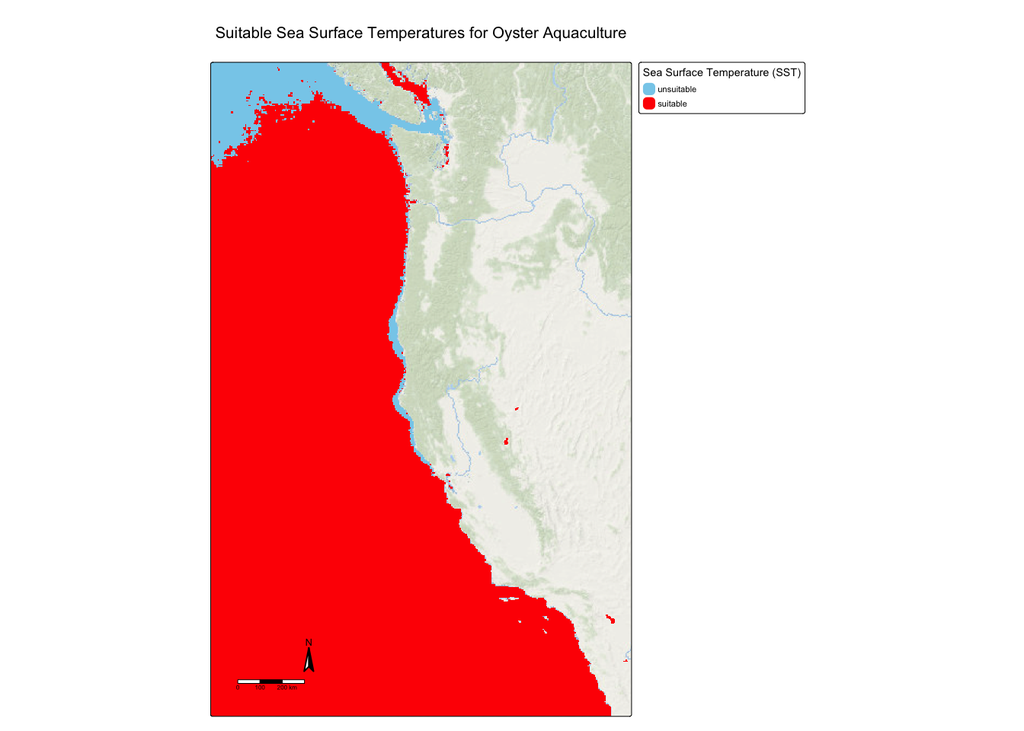

```r
# suitable depth for oyster aquaculture
tm_basemap("Esri.OceanBasemap") +
tm_shape(sst_classified) +
  tm_raster(style = "cat",
            palette = c("skyblue", "red"),
            labels = c("unsuitable", "suitable"),
            title = "Sea Surface Temperature (SST)") +
  tm_title(text = "Suitable Sea Surface Temperatures for Oyster Aquaculture",
           size = 2) +
  tm_compass() +
  tm_scalebar() +
  tm_layout(fontsize = 2,
            scale = 0.5,
            compass.position = tm_pos_in("left", "bottom"),
            scalebar.position = tm_pos_in("left", "bottom")
            )
```

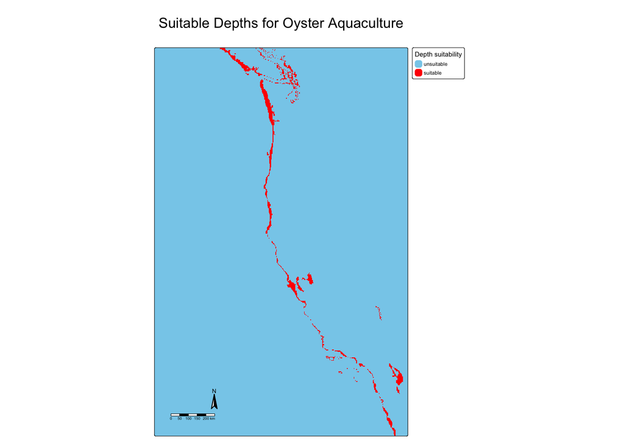

```r
# suitable depth for oyster aquaculture
tm_shape(depth_classified) +
  tm_raster(style = "cat",
            palette = c("skyblue", "red"),
            labels = c("unsuitable", "suitable"),
            title = "Depth suitability") +
  tm_title(text = "Suitable Depths for Oyster Aquaculture",
           size = 3) +
  tm_compass() +
  tm_scalebar() +
  tm_layout(fontsize = 2,
            scale = 0.5,
            compass.position = tm_pos_in("left", "bottom"),
            scalebar.position = tm_pos_in("left", "bottom")
            )
```

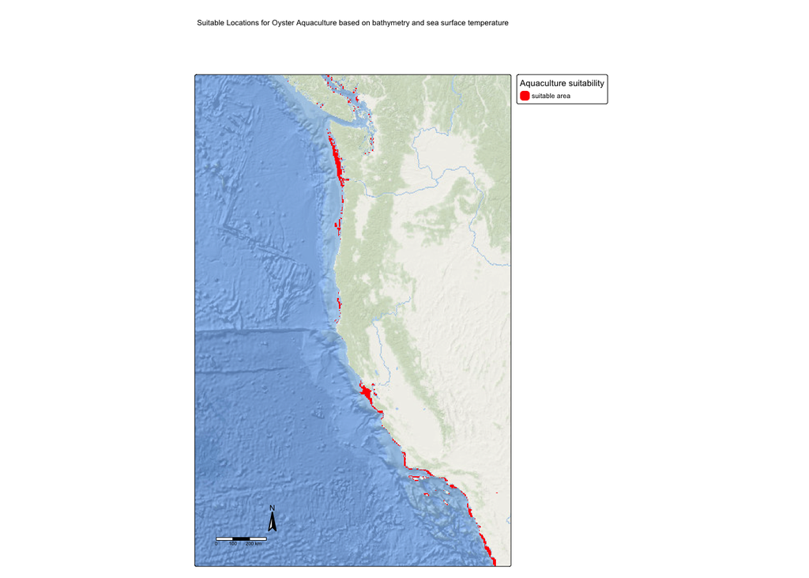

```r
# suitable locations for oyster aquaculture
tm_basemap("Esri.OceanBasemap") +
tm_shape(suit_oyster_aqu) +
  tm_raster(style = "cat",
            palette = c( "red"),
            labels = c("suitable area"),
            title = "Aquaculture suitability") +
  tm_title(text = "Suitable Locations for Oyster Aquaculture based on bathymetry and sea surface temperature",
           size = 4) +
  tm_compass() +
  tm_scalebar() +
  tm_layout(fontsize = 2,
            scale = 0.5,
            compass.position = tm_pos_in("left", "bottom"),
            scalebar.position = tm_pos_in("left", "bottom")
            )
```

# How much suitable aquaculture space is there in each Exclusive Economic Zone (EEZ)?

Find the suitable aquaculture locations for each EEZ.

```r
# rasterize the eez sf object
eez_rast <- rasterize(eez_sf, suit_oyster_aqu, field = "rgn_id")

# select only suitable oyster aquaculture locations that are within the eez
eez_oysters <- mask(suit_oyster_aqu, eez_sf)

# calculate average size of cells
avg_area <- cellSize(eez_oysters, unit = "km")

# sum the suitable aquaculture locations based on eez zones
oyst_area <- zonal(x = (eez_oysters * avg_area),
                   z = eez_rast,
                   fun = "sum",
                   na.rm = TRUE) |>
  as.data.frame()

# join to make one data frame with the total area
eez_sf <-  left_join(eez_sf, oyst_area, by = "rgn_id")

# rename new column
eez_sf <- eez_sf |>
  rename("area" = "lyr1")
```

#### How much suitable space is there for oyster aquaculture?

```r
total_oyst <- sum(eez_sf$area)
```

The total amount of space in the Exclusive Economic Zones (EEZ) on the West Coast that are suitable for oyster aquaculture based on suitable sea surface temperature and suitable bathymetry is 1.1799613^{4} km^2.

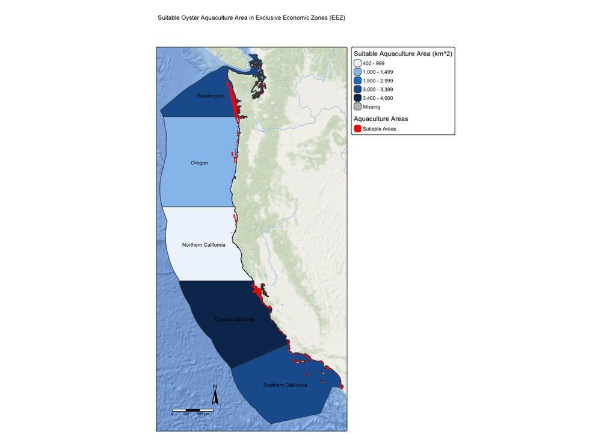

```r
tm_basemap("Esri.OceanBasemap") +
tm_shape(eez_sf) +
  tm_polygons(fill = 'area',
              breaks = c(400, 1000, 1500, 3000, 3400, 4000),
              palette = c("#EEF5FC",
                          "#96C3ED",
                          "#237DD1",
                          "#1B5E9D",
                          "#0C3259"),
              title = "Suitable Aquaculture Area (km^2)") +
  tm_text("rgn", size = 0.7) +
  tm_shape(eez_oysters) +
  tm_raster(col.scale = tm_scale_categorical(labels = (c("Suitable Areas", "Unsuitable")),
                                          values= (c("red", "white"))),
            col.legend = tm_legend("Aquaculture Areas")) +
  tm_compass() +
  tm_scalebar() +
  tm_title("Suitable Oyster Aquaculture Area in Exclusive Economic Zones (EEZ)",
           size = 3) +
  tm_layout(fontsize = 2,
            scale = 0.5,
            compass.position = tm_pos_in("left", "bottom"),
            scalebar.position = tm_pos_in("left", "bottom"))
```

```r
eez_kable <- eez_sf |>
  st_drop_geometry() |>
  rename("State" = "rgn",
         "Suitable area (km^2)" = "area")

# create a table with the counts of adequate aquaculture zones
eez_kable |>
  select("State", "Suitable area (km^2)") |>
  kbl(caption = "Suitable Oyster Aquaculture areas on the West Coast based on Exclusive Economic Zones (EEZ).") |>
  kable_styling()
```

Suitable Oyster Aquaculture areas on the West Coast based on Exclusive Economic Zones (EEZ).

| State | Suitable area (km^2) |
| --- | --- |
| Oregon | 1349.4808 |
| Northern California | 452.6195 |
| Central California | 3724.5984 |
| Southern California | 3062.2031 |
| Washington | 3210.7111 |

# Potential aquaculture locations for different species

```r
potent_aqu <- function (sst,
                        eez_sf,
                        depth,
                        min_sst,
                        max_sst,
                        min_depth,
                        max_depth,
                        species_name){

# make all of the CRS match
depth <- project(depth, crs(sst))
st_crs(eez_sf) <- crs(sst)

# calculate the mean of sst
mean_sst <- mean(sst)
# convert the units from kelvin to celcius
mean_sst <- mean_sst - 273

# crop the depth raster to match the sst extent
depth <- crop(depth, mean_sst)

# resample depth raster to match the sst resolution
depth <- resample(depth, mean_sst)

# create a classification matrix for sst
sst_matrix <- matrix(c(-Inf, min_sst, 0,
            min_sst, max_sst, 1,
            max_sst, Inf, 0),
            ncol = 3, byrow = TRUE)

# classify where suitable sst habitat for oysters are
sst_classified <- classify(mean_sst, rcl = sst_matrix)

# create a classification matrix for depth
depth_matrix = matrix(c(-Inf, min_depth, 0,
                  min_depth, max_depth, 1,
                  max_depth, Inf, 0),
                  ncol = 3, byrow = TRUE)

# classify where suitable depth habitat for oysters are
depth_classified <- classify(depth, rcl = depth_matrix)

# function to determine what habitats are suitable
suitable_habitat <- function(rast1, rast2){

  rast1 * rast2
}

# find suitable locations for aquaculture
suit_aqu <- lapp(c(sst_classified, depth_classified), fun = suitable_habitat)

# rasterize the eez sf object
eez_rast <- rasterize(eez_sf, suit_aqu, field = "rgn_id")

# set any locations with a zero to NA
suit_aqu[suit_aqu == 0] <- NA

# select only suitable oyster aquaculture locations that are within the eez
eez_spec <- mask(suit_aqu, eez_sf)

# calculate average size of cells
avg_area <- cellSize(eez_spec, unit = "km")

# sum the suitable aquaculture locations based on eez zones
spec_area <- zonal(x = (eez_spec * avg_area),
                   z = eez_rast,
                   fun = "sum",
                   na.rm = TRUE) |>
              as.data.frame()

# join to make one data frame with the total area
spec_area_eez <-  left_join(eez_sf, spec_area, by = "rgn_id")

# rename new column
spec_area_eez <- spec_area_eez |>
  rename("spec_area" = "lyr1")

# map the eez's based on the amount of suitable area per region
tm_basemap("Esri.OceanBasemap") +
tm_shape(spec_area_eez) +
  tm_polygons(fill = "spec_area",
              fill.legend = tm_legend("Suitable Aquaculture Area (km^2)")) +
  tm_text("rgn", size = 0.7) +
  tm_shape(eez_oysters) +
  tm_raster(col.scale = tm_scale_categorical(labels = (c("Suitable Areas", "Unsuitable")),
                                          values= (c("red", "white"))),
            col.legend = tm_legend("Aquaculture Areas")) +
  tm_compass() +
  tm_scalebar() +
  tm_title( paste("Suitable Aquaculture Area in Exclusive Economic Zones (EEZ): ", species_name),
           size = 2) +
  tm_layout(fontsize = 2,
            scale = 0.5,
            compass.position = tm_pos_in("left", "bottom"),
            scalebar.position = tm_pos_in("left", "bottom")
            )
}
```

# Additional species of interest: **Red Sea Urchin**, *Mesocentrotus franciscanus*

Sea surface temperature is adequate for red sea urchins in the range of 6.75-13.02°C. Red sea urchins can survive between the depths of 125 and 0 meters below the sea surface.

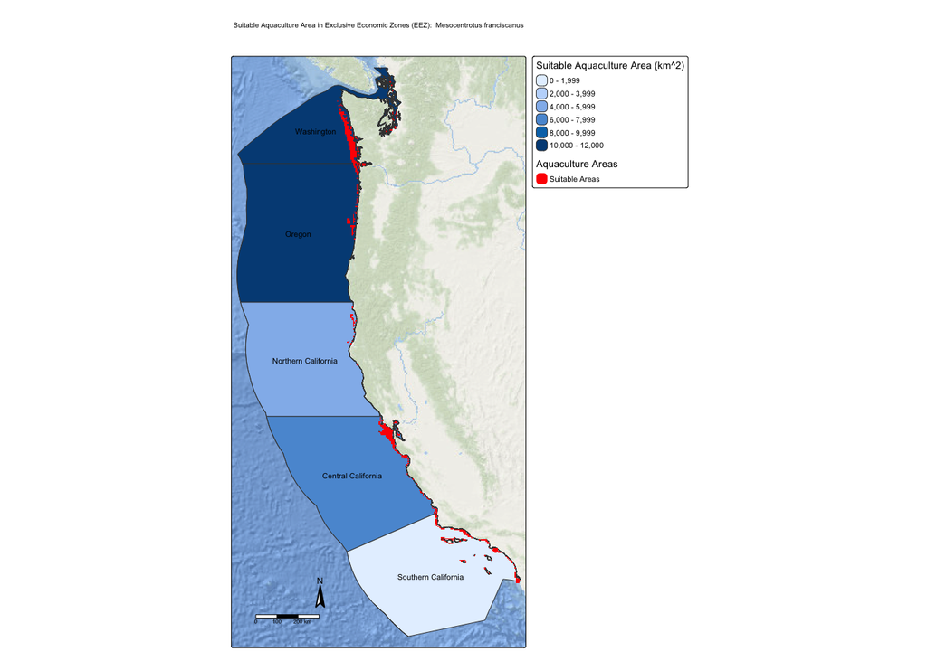

```r
# run the function to identify potential suitable areas for red sea urchin aquaculture
potent_aqu(sst, eez_sf, depth, 6.75, 13.02, -125, 0, "Mesocentrotus franciscanus")
```

# Reflection

Analyzing potential aquaculture locations based on SST and bathymetry is only the first step in finding suitable locations for new aquaculture endeavors. One limitation of the above analysis is that SST is an average taken from 2008 to 2012. With climate change shifting temperatures, projection data would be important to include in analyzing best future aquaculture sites. Referencing species native ranges is also essential to reducing any potential negative outcomes of introducing non-native species.

# References

Flanders Marine Institute (2025): MarineRegions.org. Available online at www.marineregions.org. Consulted on 2025-11-14.

Gentry, R. R., Froehlich, H. E., Grimm, D., Kareiva, P., Parke, M., Rust, M., Gaines, S. D., & Halpern, B. S. Mapping the global potential for marine aquaculture. Nature Ecology & Evolution, 1, 1317-1324 (2017).

GEBCO Compilation Group (2022) GEBCO_2022 Grid (doi:10.5285/e0f0bb80-ab44-2739-e053-6c86abc0289c).

Hall, S. J., Delaporte, A., Phillips, M. J., Beveridge, M. & O’Keefe, M. Blue Frontiers: Managing the Environmental Costs of Aquaculture (The WorldFish Center, Penang, Malaysia, 2011).

NOAA Coral Reef Watch. 2019, updated daily. NOAA’s 5km Daily Global Satellite Sea Surface Temperature Anomaly v3.1 for the West Coast, 2008 - 2012. College Park, Maryland, USA: NOAA Coral Reef Watch. Data set accessed 2025-11-14 at https://coralreefwatch.noaa.gov/product/5km/index_5km_ssta.php.

Palomares, M.L.D. and D. Pauly. Editors. 2025. SeaLifeBase. World Wide Web electronic publication. www.sealifebase.org, version (04/2025).